# my second final project

```python
import numpy as np
import pandas as pd
import matplotlib.pyplot as plt
```

```python
data=pd.read_csv("D:\\projects\\capstone projct\\Capstone-project-2 (1) (1)\\Dataset\\Dataset\\customer_churn.csv")
```

```python
data.count()
```

```
customerID          7043
gender              7043
SeniorCitizen       7043
Partner             7043
Dependents          7043
tenure              7043
PhoneService        7043
MultipleLines       7043
InternetService     7043
OnlineSecurity      7043
OnlineBackup        7043
DeviceProtection    7043
TechSupport         7043
StreamingTV         7043
StreamingMovies     7043
Contract            7043
PaperlessBilling    7043
PaymentMethod       7043
MonthlyCharges      7043
TotalCharges        7043
Churn               7043
dtype: int64
```

```python
data.isnull().sum()
```

```
customerID          0
gender              0
SeniorCitizen       0
Partner             0
Dependents          0
tenure              0
PhoneService        0
MultipleLines       0
InternetService     0
OnlineSecurity      0
OnlineBackup        0
DeviceProtection    0
TechSupport         0
StreamingTV         0
StreamingMovies     0
Contract            0
PaperlessBilling    0
PaymentMethod       0
MonthlyCharges      0
TotalCharges        0
Churn               0
dtype: int64
```

```python
data.dtypes
```

```
customerID           object
gender               object
SeniorCitizen         int64
Partner              object
Dependents           object
tenure                int64
PhoneService         object
MultipleLines        object
InternetService      object
OnlineSecurity       object
OnlineBackup         object
DeviceProtection     object
TechSupport          object
StreamingTV          object
StreamingMovies      object
Contract             object
PaperlessBilling     object
PaymentMethod        object
MonthlyCharges      float64
TotalCharges         object
Churn                object
dtype: object
```

```python
data[['SeniorCitizen','PaymentMethod']].value_counts()
```

```
SeniorCitizen  PaymentMethod
0              Electronic check             1771
               Mailed check                 1518
               Bank transfer (automatic)    1311
               Credit card (automatic)      1301
1              Electronic check              594
               Bank transfer (automatic)     233
               Credit card (automatic)       221
               Mailed check                   94
dtype: int64
```

# a.Extract the 5th column & store it in ‘customer_5’

```python
customer_5=data.iloc[:,[4]]
```

```python
customer_5.head()
```

|  | Dependents |
| --- | --- |
| 0 | No |
| 1 | No |
| 2 | No |
| 3 | No |
| 4 | No |

# b.Extract the 15th column & store it in ‘customer_15’

```python
customer_15=data.iloc[:,[14]]
```

```python
customer_15.head()
```

|  | StreamingMovies |
| --- | --- |
| 0 | No |
| 1 | No |
| 2 | No |
| 3 | No |
| 4 | No |

# c.Extract all the male senior citizens whose Payment Method is Electronic check & store the result in ‘senior_male_electronic’

```python
data[['gender','SeniorCitizen','PaymentMethod']].value_counts()
```

```
gender  SeniorCitizen  PaymentMethod
Male    0              Electronic check             897
Female  0              Electronic check             874
Male    0              Mailed check                 790
Female  0              Mailed check                 728
                       Bank transfer (automatic)    676
Male    0              Credit card (automatic)      659
Female  0              Credit card (automatic)      642
Male    0              Bank transfer (automatic)    635
        1              Electronic check             298
Female  1              Electronic check             296
Male    1              Bank transfer (automatic)    121
Female  1              Bank transfer (automatic)    112
Male    1              Credit card (automatic)      111
Female  1              Credit card (automatic)      110
                       Mailed check                  50
Male    1              Mailed check                  44
dtype: int64
```

```python
data[['gender','SeniorCitizen','PaymentMethod']].head()
```

|  | gender | SeniorCitizen | PaymentMethod |
| --- | --- | --- | --- |
| 0 | Female | 0 | Electronic check |
| 1 | Male | 0 | Mailed check |
| 2 | Male | 0 | Mailed check |
| 3 | Male | 0 | Bank transfer (automatic) |
| 4 | Female | 0 | Electronic check |

```python
senior_male_electronic=data[(data['gender']=='Male') & (data['SeniorCitizen']==1) & (data['PaymentMethod']=='Electronic check')]
```

```python
senior_male_electronic.head()
```

|  | customerID | gender | SeniorCitizen | Partner | Dependents | tenure | PhoneService | MultipleLines | InternetService | OnlineSecurity | ... | DeviceProtection | TechSupport | StreamingTV | StreamingMovies | Contract | PaperlessBilling | PaymentMethod | MonthlyCharges | TotalCharges | Churn |
| --- | --- | --- | --- | --- | --- | --- | --- | --- | --- | --- | --- | --- | --- | --- | --- | --- | --- | --- | --- | --- | --- |
| 20 | 8779-QRDMV | Male | 1 | No | No | 1 | No | No phone service | DSL | No | ... | Yes | No | No | Yes | Month-to-month | Yes | Electronic check | 39.65 | 39.65 | Yes |
| 55 | 1658-BYGOY | Male | 1 | No | No | 18 | Yes | Yes | Fiber optic | No | ... | No | No | Yes | Yes | Month-to-month | Yes | Electronic check | 95.45 | 1752.55 | Yes |
| 57 | 5067-XJQFU | Male | 1 | Yes | Yes | 66 | Yes | Yes | Fiber optic | No | ... | Yes | Yes | Yes | Yes | One year | Yes | Electronic check | 108.45 | 7076.35 | No |
| 78 | 0191-ZHSKZ | Male | 1 | No | No | 30 | Yes | No | DSL | Yes | ... | No | No | Yes | Yes | Month-to-month | Yes | Electronic check | 74.75 | 2111.3 | No |
| 91 | 2424-WVHPL | Male | 1 | No | No | 1 | Yes | No | Fiber optic | No | ... | No | Yes | No | No | Month-to-month | No | Electronic check | 74.70 | 74.7 | No |

5 rows × 21 columns

# d. Extract all those customers whose tenure is greater than 70 months or their Monthly charges is more than 100 & store the result in ‘customer_total_tenure’

```python
data[['tenure','MonthlyCharges']].value_counts()
```

```
tenure  MonthlyCharges
1       20.20             11
        19.75              9
        19.90              8
        20.05              8
        19.65              8
                          ..
19      44.90              1
        44.85              1
        39.70              1
        39.65              1
72      118.75             1
Length: 6329, dtype: int64
```

```python
customer_total_tenure=data[(data['tenure']>70) | (data['MonthlyCharges']>100)]
```

```python
customer_total_tenure.head()
```

|  | customerID | gender | SeniorCitizen | Partner | Dependents | tenure | PhoneService | MultipleLines | InternetService | OnlineSecurity | ... | DeviceProtection | TechSupport | StreamingTV | StreamingMovies | Contract | PaperlessBilling | PaymentMethod | MonthlyCharges | TotalCharges | Churn |
| --- | --- | --- | --- | --- | --- | --- | --- | --- | --- | --- | --- | --- | --- | --- | --- | --- | --- | --- | --- | --- | --- |
| 8 | 7892-POOKP | Female | 0 | Yes | No | 28 | Yes | Yes | Fiber optic | No | ... | Yes | Yes | Yes | Yes | Month-to-month | Yes | Electronic check | 104.80 | 3046.05 | Yes |
| 12 | 8091-TTVAX | Male | 0 | Yes | No | 58 | Yes | Yes | Fiber optic | No | ... | Yes | No | Yes | Yes | One year | No | Credit card (automatic) | 100.35 | 5681.1 | No |
| 13 | 0280-XJGEX | Male | 0 | No | No | 49 | Yes | Yes | Fiber optic | No | ... | Yes | No | Yes | Yes | Month-to-month | Yes | Bank transfer (automatic) | 103.70 | 5036.3 | Yes |
| 14 | 5129-JLPIS | Male | 0 | No | No | 25 | Yes | No | Fiber optic | Yes | ... | Yes | Yes | Yes | Yes | Month-to-month | Yes | Electronic check | 105.50 | 2686.05 | No |
| 15 | 3655-SNQYZ | Female | 0 | Yes | Yes | 69 | Yes | Yes | Fiber optic | Yes | ... | Yes | Yes | Yes | Yes | Two year | No | Credit card (automatic) | 113.25 | 7895.15 | No |

5 rows × 21 columns

# e. Extract all the customers whose Contract is of two years, payment method is Mailed check & the value of Churn is ‘Yes’ & store the result in ‘two_mail_yes’

```python
data[['Contract','PaymentMethod','Churn']].value_counts()
```

```
Contract        PaymentMethod              Churn
Month-to-month  Electronic check           Yes      994
                                           No       856
                Mailed check               No       611
Two year        Credit card (automatic)    No       568
                Bank transfer (automatic)  No       545
Month-to-month  Bank transfer (automatic)  No       388
Two year        Mailed check               No       379
Month-to-month  Credit card (automatic)    No       365
One year        Credit card (automatic)    No       357
                Bank transfer (automatic)  No       353
                Mailed check               No       314
                Electronic check           No       283
Month-to-month  Mailed check               Yes      282
                Bank transfer (automatic)  Yes      201
                Credit card (automatic)    Yes      178
Two year        Electronic check           No       155
One year        Electronic check           Yes       64
                Credit card (automatic)    Yes       41
                Bank transfer (automatic)  Yes       38
                Mailed check               Yes       23
Two year        Bank transfer (automatic)  Yes       19
                Credit card (automatic)    Yes       13
                Electronic check           Yes       13
                Mailed check               Yes        3
dtype: int64
```

```python
two_mail_yes=data[(data['Contract']=='Two year') &(data['PaymentMethod']=='Mailed check') &(data['Churn']=='Yes')]
```

```python
two_mail_yes.head()
```

|  | customerID | gender | SeniorCitizen | Partner | Dependents | tenure | PhoneService | MultipleLines | InternetService | OnlineSecurity | ... | DeviceProtection | TechSupport | StreamingTV | StreamingMovies | Contract | PaperlessBilling | PaymentMethod | MonthlyCharges | TotalCharges | Churn |
| --- | --- | --- | --- | --- | --- | --- | --- | --- | --- | --- | --- | --- | --- | --- | --- | --- | --- | --- | --- | --- | --- |
| 268 | 6323-AYBRX | Male | 0 | No | No | 59 | Yes | No | No | No internet service | ... | No internet service | No internet service | No internet service | No internet service | Two year | No | Mailed check | 19.35 | 1099.6 | Yes |
| 5947 | 7951-QKZPL | Female | 0 | Yes | Yes | 33 | Yes | Yes | No | No internet service | ... | No internet service | No internet service | No internet service | No internet service | Two year | Yes | Mailed check | 24.50 | 740.3 | Yes |
| 6680 | 9412-ARGBX | Female | 0 | No | Yes | 48 | Yes | No | Fiber optic | No | ... | Yes | Yes | Yes | No | Two year | Yes | Mailed check | 95.50 | 4627.85 | Yes |

3 rows × 21 columns

# f. Extract 333 random records from the customer_churn dataframe & store the result in ‘customer_333’

```python
import random
```

```python
da=random.randint(0,33)
```

```python
da
```

```
4
```

```python
#for i in range(0,333):
#   da=random.randint(0,7043)
#   m=data.iloc[[da],:]
#  print(m)
```

```python
data.iloc[[2],:]
```

|  | customerID | gender | SeniorCitizen | Partner | Dependents | tenure | PhoneService | MultipleLines | InternetService | OnlineSecurity | ... | DeviceProtection | TechSupport | StreamingTV | StreamingMovies | Contract | PaperlessBilling | PaymentMethod | MonthlyCharges | TotalCharges | Churn |
| --- | --- | --- | --- | --- | --- | --- | --- | --- | --- | --- | --- | --- | --- | --- | --- | --- | --- | --- | --- | --- | --- |
| 2 | 3668-QPYBK | Male | 0 | No | No | 2 | Yes | No | DSL | Yes | ... | No | No | No | No | Month-to-month | Yes | Mailed check | 53.85 | 108.15 | Yes |

1 rows × 21 columns

```python
data.sample()
```

|  | customerID | gender | SeniorCitizen | Partner | Dependents | tenure | PhoneService | MultipleLines | InternetService | OnlineSecurity | ... | DeviceProtection | TechSupport | StreamingTV | StreamingMovies | Contract | PaperlessBilling | PaymentMethod | MonthlyCharges | TotalCharges | Churn |
| --- | --- | --- | --- | --- | --- | --- | --- | --- | --- | --- | --- | --- | --- | --- | --- | --- | --- | --- | --- | --- | --- |
| 4369 | 2592-SEIFQ | Male | 0 | No | No | 3 | No | No phone service | DSL | No | ... | No | No | No | No | Month-to-month | No | Electronic check | 24.75 | 66.95 | Yes |

1 rows × 21 columns

```python
customer_333=data.sample(n=333)
```

```python
customer_333
```

|  | customerID | gender | SeniorCitizen | Partner | Dependents | tenure | PhoneService | MultipleLines | InternetService | OnlineSecurity | ... | DeviceProtection | TechSupport | StreamingTV | StreamingMovies | Contract | PaperlessBilling | PaymentMethod | MonthlyCharges | TotalCharges | Churn |
| --- | --- | --- | --- | --- | --- | --- | --- | --- | --- | --- | --- | --- | --- | --- | --- | --- | --- | --- | --- | --- | --- |
| 4848 | 5380-AFSSK | Female | 0 | No | No | 5 | Yes | Yes | Fiber optic | No | ... | No | No | Yes | Yes | Month-to-month | Yes | Mailed check | 93.90 | 486.85 | Yes |
| 4736 | 3050-RLLXC | Female | 0 | Yes | Yes | 56 | Yes | Yes | DSL | Yes | ... | Yes | Yes | Yes | No | Two year | No | Credit card (automatic) | 81.25 | 4620.4 | No |
| 4203 | 4291-YZODP | Female | 0 | No | Yes | 7 | Yes | No | No | No internet service | ... | No internet service | No internet service | No internet service | No internet service | One year | No | Mailed check | 20.05 | 96.8 | No |
| 306 | 0265-EDXBD | Male | 1 | Yes | No | 32 | Yes | Yes | Fiber optic | No | ... | No | No | No | No | Month-to-month | Yes | Electronic check | 74.90 | 2303.35 | Yes |
| 6920 | 2595-KIWPV | Male | 0 | No | Yes | 27 | Yes | No | No | No internet service | ... | No internet service | No internet service | No internet service | No internet service | Two year | No | Credit card (automatic) | 19.70 | 509.3 | No |
| ... | ... | ... | ... | ... | ... | ... | ... | ... | ... | ... | ... | ... | ... | ... | ... | ... | ... | ... | ... | ... | ... |
| 2027 | 3778-FOAQW | Female | 0 | Yes | No | 24 | Yes | No | No | No internet service | ... | No internet service | No internet service | No internet service | No internet service | One year | No | Mailed check | 20.15 | 456.85 | No |
| 4200 | 8316-BBQAY | Female | 0 | No | No | 65 | No | No phone service | DSL | Yes | ... | Yes | Yes | Yes | Yes | Two year | No | Credit card (automatic) | 59.95 | 3921.1 | No |
| 3048 | 1728-BQDMA | Female | 0 | No | No | 2 | Yes | No | DSL | No | ... | No | No | No | No | Month-to-month | No | Electronic check | 44.45 | 82.7 | No |
| 6921 | 5243-SAOTC | Male | 0 | No | No | 54 | Yes | Yes | Fiber optic | No | ... | No | No | No | No | Month-to-month | Yes | Bank transfer (automatic) | 79.85 | 4308.25 | No |
| 3983 | 1334-FJSVR | Male | 0 | No | No | 1 | No | No phone service | DSL | No | ... | No | No | No | No | Month-to-month | Yes | Electronic check | 24.25 | 24.25 | Yes |

333 rows × 21 columns

# g. Get the count of different levels from the ‘Churn’ column

```python
data['Churn'].value_counts()
```

```
No     5174
Yes    1869
Name: Churn, dtype: int64
```

```python
data.head()
```

|  | customerID | gender | SeniorCitizen | Partner | Dependents | tenure | PhoneService | MultipleLines | InternetService | OnlineSecurity | ... | DeviceProtection | TechSupport | StreamingTV | StreamingMovies | Contract | PaperlessBilling | PaymentMethod | MonthlyCharges | TotalCharges | Churn |
| --- | --- | --- | --- | --- | --- | --- | --- | --- | --- | --- | --- | --- | --- | --- | --- | --- | --- | --- | --- | --- | --- |
| 0 | 7590-VHVEG | Female | 0 | Yes | No | 1 | No | No phone service | DSL | No | ... | No | No | No | No | Month-to-month | Yes | Electronic check | 29.85 | 29.85 | No |
| 1 | 5575-GNVDE | Male | 0 | No | No | 34 | Yes | No | DSL | Yes | ... | Yes | No | No | No | One year | No | Mailed check | 56.95 | 1889.5 | No |
| 2 | 3668-QPYBK | Male | 0 | No | No | 2 | Yes | No | DSL | Yes | ... | No | No | No | No | Month-to-month | Yes | Mailed check | 53.85 | 108.15 | Yes |
| 3 | 7795-CFOCW | Male | 0 | No | No | 45 | No | No phone service | DSL | Yes | ... | Yes | Yes | No | No | One year | No | Bank transfer (automatic) | 42.30 | 1840.75 | No |
| 4 | 9237-HQITU | Female | 0 | No | No | 2 | Yes | No | Fiber optic | No | ... | No | No | No | No | Month-to-month | Yes | Electronic check | 70.70 | 151.65 | Yes |

5 rows × 21 columns

```python
data.count()
```

```
customerID          7043
gender              7043
SeniorCitizen       7043
Partner             7043
Dependents          7043
tenure              7043
PhoneService        7043
MultipleLines       7043
InternetService     7043
OnlineSecurity      7043
OnlineBackup        7043
DeviceProtection    7043
TechSupport         7043
StreamingTV         7043
StreamingMovies     7043
Contract            7043
PaperlessBilling    7043
PaymentMethod       7043
MonthlyCharges      7043
TotalCharges        7043
Churn               7043
dtype: int64
```

# B) Data Visualization:

```
  a.    Build a bar-plot for the ’InternetService’ column:
      i.    Set x-axis label to ‘Categories of Internet Service’
      ii.   Set y-axis label to ‘Count of Categories’
      iii.  Set the title of plot to be ‘Distribution of Internet Service’
      iv.   Set the color of the bars to be ‘orange’
```

```python
x=data['InternetService'].value_counts().keys().tolist()
```

```python
y=data['InternetService'].value_counts()
```

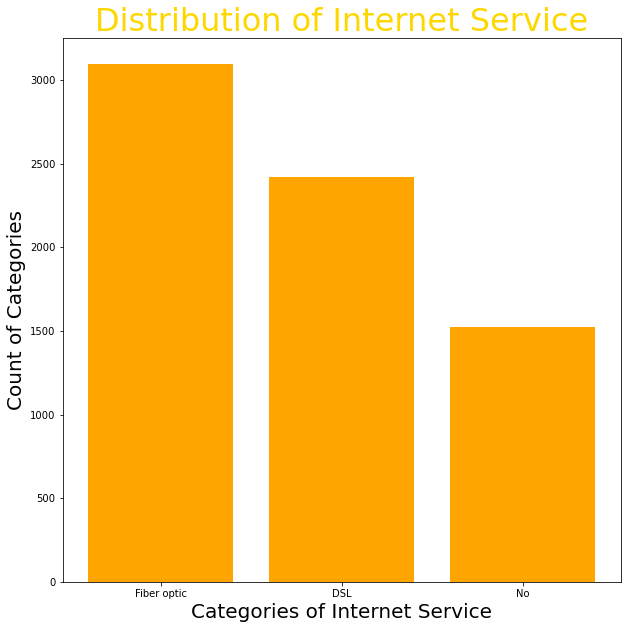

```python
plt.figure(figsize=(10,10))
plt.bar(x,y,color='orange')
plt.xlabel('Categories of Internet Service',size=20)
plt.ylabel('Count of Categories',size=20)
plt.title('Distribution of Internet Service',size=32,color='gold')
```

# b. Build a histogram for the ‘tenure’ column:

```
   i.   Set the number of bins to be 30
   ii.  Set the color of the bins  to be ‘green’
   iii. Assign the title ‘Distribution of tenure’
```

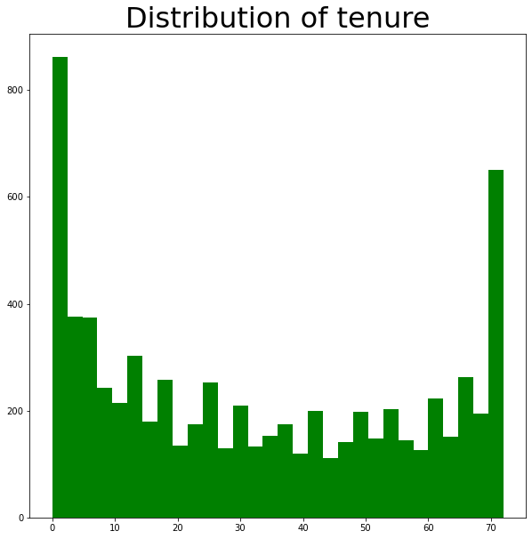

```python
plt.figure(figsize=(10,10))
plt.hist(data['tenure'],color='green',bins=30)
plt.title('Distribution of tenure',size=32)
```

# c. Build a scatter-plot between ‘MonthlyCharges’ & ‘tenure’. Map ‘MonthlyCharges’ to the y-axis & ‘tenure’ to the ‘x-axis’:

```
i.  Assign the points a color of ‘brown’
ii. Set the x-axis label to ‘Tenure of customer’
iii.    Set the y-axis label to ‘Monthly Charges of customer’
iv. Set the title to ‘Tenure vs Monthly Charges’
```

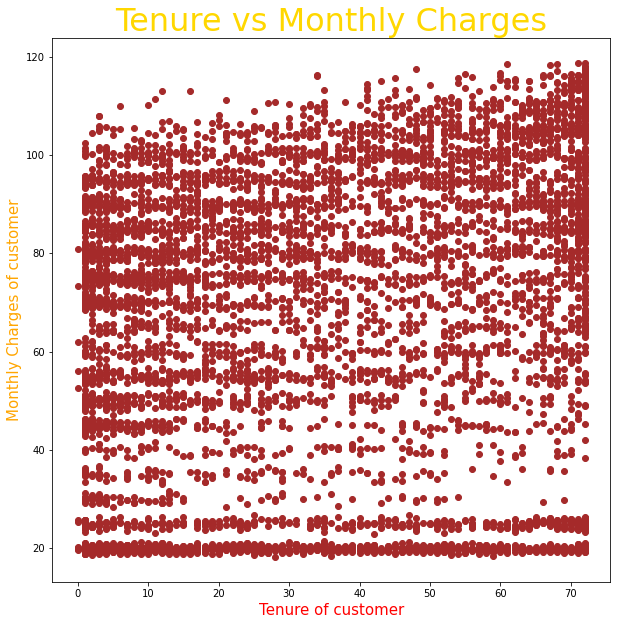

```python
plt.figure(figsize=(10,10))
plt.scatter(data['tenure'],data['MonthlyCharges'],color='brown')
plt.xlabel('Tenure of customer',size=15,color='red')
plt.ylabel('Monthly Charges of customer',size=15,color='orange')
plt.title('Tenure vs Monthly Charges',size=32,color='gold')
```

# d. Build a box-plot between ‘tenure’ & ‘Contract’. Map ‘tenure’ on the y-axis & ‘Contract’ on the x-axis.

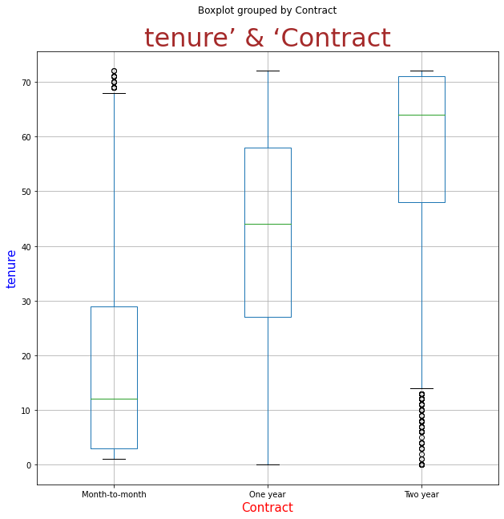

```python
data.boxplot(column='tenure',by=['Contract'],figsize=(10,10))
plt.title('tenure’ & ‘Contract',size=32,color='brown')
plt.xlabel('Contract',size=15,color='red')
plt.ylabel('tenure',size=15,color='blue')
```

# C) Linear Regression:

```python
x=data['tenure'] #independent
y=data['MonthlyCharges'] #dependent
```

```python
from sklearn.model_selection import train_test_split
from sklearn.linear_model import LinearRegression
from sklearn.metrics import mean_squared_error
```

```python
x_train,x_test,y_train,y_test=train_test_split(x,y,test_size=.30)
```

```python
x_train=pd.DataFrame(x_train)
```

```python
x_test=pd.DataFrame(x_test)
```

```python
linear=LinearRegression()
```

```python
linear.fit(x_train,y_train)
```

```
LinearRegression()
```

```python
y_predict=linear.predict(x_test)
```

```python
msr=mean_squared_error(y_test,y_predict)
```

```python
Rootmsr=np.sqrt(msr)
```

```python
from sklearn.linear_model import Lasso
```

```python
model1=Lasso()
```

```python
print('mean_squared_error           :',msr)
print('Root of mean_squared_error   :',Rootmsr)
```

```
mean_squared_error           : 829.5870947426664
Root of mean_squared_error   : 28.802553614960367
```

# D) Logistic Regression:

a. Build a simple logistic regression model where dependent variable is ‘Churn’ & independent variable is ‘MonthlyCharges’ i. Divide the dataset in 65:35 ratio ii. Build the model on train set and predict the values on test set iii. Build the confusion matric and get the accuracy score

```python
x=pd.DataFrame(data['MonthlyCharges'])
y=data['Churn']
```

```python
from sklearn.model_selection import train_test_split
from sklearn.linear_model import LogisticRegression
from sklearn.metrics import accuracy_score
```

```python
x_train,x_test,y_train,y_test=train_test_split(x,y,test_size=.35)
logistic=LogisticRegression()
```

```python
logistic.fit(x_train,y_train)
```

```
LogisticRegression()
```

```python
y_predict=logistic.predict(x_test)
```

```python
score=accuracy_score(y_predict,y_test)
```

```python
print('Accuracy score :',score)
```

```
Accuracy score : 0.7307380373073804
```

# b. Build a multiple logistic regression model where dependent variable is ‘Churn’ & independent variables are ‘tenure’ & ‘MonthlyCharges’

i. Divide the dataset in 80:20 ratio ii. Build the model on train set and predict the values on test set iii. Build the confusion matrix and get the accuracy score

```python
x=pd.DataFrame(data[['tenure','MonthlyCharges']])
y=data['Churn']
```

```python
x.head()
```

|  | tenure | MonthlyCharges |
| --- | --- | --- |
| 0 | 1 | 29.85 |
| 1 | 34 | 56.95 |
| 2 | 2 | 53.85 |
| 3 | 45 | 42.30 |
| 4 | 2 | 70.70 |

```python
from sklearn.model_selection import train_test_split
from sklearn.linear_model import LogisticRegression
from sklearn.metrics import accuracy_score,confusion_matrix,classification_report
```

```python
x_train,x_test,y_train,y_test=train_test_split(x,y,test_size=.20)
logistic=LogisticRegression()
```

```python
x_train.head()
```

|  | tenure | MonthlyCharges |
| --- | --- | --- |
| 6901 | 30 | 68.95 |
| 1490 | 66 | 70.85 |
| 2795 | 9 | 74.55 |
| 4928 | 4 | 46.00 |
| 4655 | 32 | 74.75 |

```python
logistic.fit(x_train,y_train)
```

```
LogisticRegression()
```

```python
y_predict=logistic.predict(x_test)
```

```python
con_matrix=confusion_matrix(y_predict,y_test)
```

```python
accu=accuracy_score(y_predict,y_test)
```

```python
print('confusion_matrix :')
print(con_matrix)
print('---------------------------------')
print('accuracy_score   :',accu)
print('---------------------------------')
print('classification_report')
print(classification_report(y_predict,y_test))
```

```
confusion_matrix :
[[959 212]
 [ 90 148]]
---------------------------------
accuracy_score   : 0.7856635911994322
---------------------------------
classification_report
              precision    recall  f1-score   support

          No       0.91      0.82      0.86      1171
         Yes       0.41      0.62      0.49       238

    accuracy                           0.79      1409
   macro avg       0.66      0.72      0.68      1409
weighted avg       0.83      0.79      0.80      1409
```

# E) Decision Tree:

a. Build a decision tree model where dependent variable is ‘Churn’ & independent variable is ‘tenure’ i. Divide the dataset in 80:20 ratio ii. Build the model on train set and predict the values on test set iii.Build the confusion matrix and calculate the accuracy

```python
x=pd.DataFrame(data['tenure'])
y=data['Churn']
```

```python
x.head()
```

|  | tenure |
| --- | --- |
| 0 | 1 |
| 1 | 34 |
| 2 | 2 |
| 3 | 45 |
| 4 | 2 |

```python
from sklearn.tree import DecisionTreeClassifier
```

```python
x_train,x_test,y_train,y_test=train_test_split(x,y,test_size=.20)
```

```python
x_train.head()
```

|  | tenure |
| --- | --- |
| 3431 | 24 |
| 2821 | 1 |
| 481 | 48 |
| 3057 | 25 |
| 458 | 2 |

```python
d_tree=DecisionTreeClassifier()
```

```python
d_tree.fit(x_train,y_train)
```

```
DecisionTreeClassifier()
```

```python
y_predict=d_tree.predict(x_test)
```

```python
con_matrix_tree=confusion_matrix(y_predict,y_test)
acc_tree=accuracy_score(y_predict,y_test)
```

```python
print('confusion_matrix :')
print(con_matrix_tree)
print('---------------------------------')
print('accuracy_score   :',acc_tree)
print('---------------------------------')
print('classification_report')
print(classification_report(y_predict,y_test))
```

```
confusion_matrix :
[[965 258]
 [ 84 102]]
---------------------------------
accuracy_score   : 0.7572746628814763
---------------------------------
classification_report
              precision    recall  f1-score   support

          No       0.92      0.79      0.85      1223
         Yes       0.28      0.55      0.37       186

    accuracy                           0.76      1409
   macro avg       0.60      0.67      0.61      1409
weighted avg       0.84      0.76      0.79      1409
```

# F) Random Forest:

```python
x=data[['tenure','MonthlyCharges']]
y=data['Churn']
```

```python
x.head()
```

|  | tenure | MonthlyCharges |
| --- | --- | --- |
| 0 | 1 | 29.85 |
| 1 | 34 | 56.95 |
| 2 | 2 | 53.85 |
| 3 | 45 | 42.30 |
| 4 | 2 | 70.70 |

```python
x_train,x_test,y_train,y_test=train_test_split(x,y,test_size=.20)
```

```python
from sklearn.ensemble import RandomForestClassifier
r_tree=RandomForestClassifier(n_estimators=100)
r_tree.fit(x_train,y_train)
```

```
RandomForestClassifier()
```

```python
y_predict=r_tree.predict(x_test)
```

```python
con_matrix_r_tree=confusion_matrix(y_predict,y_test)
acc_r_tree=accuracy_score(y_predict,y_test)
```

```python
print('confusion_matrix :')
print(con_matrix_r_tree)
print('---------------------------------')
print('accuracy_score   :',acc_r_tree)
print('---------------------------------')
print('classification_report')
print(classification_report(y_predict,y_test))
```

```
confusion_matrix :
[[879 213]
 [152 165]]
---------------------------------
accuracy_score   : 0.7409510290986515
---------------------------------
classification_report
              precision    recall  f1-score   support

          No       0.85      0.80      0.83      1092
         Yes       0.44      0.52      0.47       317

    accuracy                           0.74      1409
   macro avg       0.64      0.66      0.65      1409
weighted avg       0.76      0.74      0.75      1409
```